# DS養成講座 Jリーグ観客動員数を予測せよ！

Shinji KAWASOE

Data : 2017-12-18

# 1 データの中を調べる。

データ探索を「Exploratory Data Analysis」と言うらしい。

# 2 データ加工

```r
## 使用ライブラリ
library(tidyverse)
library(modelr)
library(knitr)
```

```r
## データ読込(結合したデータ)
train<-read.csv("../data/train_new.csv", #読込ファイル
                header=TRUE, #読込データのヘッダー有無
                stringsAsFactors=FALSE #文字列の読込時の型指定(character)
)
test<-read.csv("../data/test_new.csv",
               header=TRUE,
               stringsAsFactors=FALSE)
```

# 3 Variable Conversionの詳細確認

目的変数(観客数)を直接予測するではなく、試合の行なわれるスタジアムの収容率を予測して、最後に観客数に戻すことを行なう。

1. 目的変数を収容率に変換。$y_1$:観客動員数、capa:スタジアム収容人数として、

$y_2 = \frac{y_1}{capa}.$

2. 次に、対数オッズに変換する。

$y_3 = log(\frac{y_2}{1-y_2}).$

3. この$y_3$を線形回帰モデルを用いて予測する。このとこ、変数加工(変数作成、線形化など)やデータ 加工(欠損、外れ値処理)、変数選択(変数同士の相関確認)などを忘れないように。
4. 予測されて$\hat{y_3}$を収容率に戻します。このとき、対数オッズ変換の逆関数はロジスティク関数となる。

$\hat{y_2} = \frac{1}{1+e^{-\hat{y_3}}}.$

5. 最後に収容率から観客数に変換する。

$\hat{y_1} = capa * \hat{y_2}.$

```r
## 観客数0の場合は除く(異常値なのと、対数オッズが発散するため)
train <- train %>%
    dplyr::filter(y != 0)

## 予測するy_3の作成
train <- train %>%
    dplyr::mutate(
               y_2 = y / capa,
               y_3 = log(y_2 / (1 - y_2)))

## TV放送数の追加
train$tv_num <- sapply(strsplit(train$tv, "／"), length) - 1

## 収容率の範囲
summary(train$y /train$capa)
```

```
##    Min. 1st Qu.  Median    Mean 3rd Qu.    Max.
## 0.05061 0.24649 0.38781 0.42090 0.57269 0.97900
```

最小値が0%より大きく、最大値が100%未満であることを確認する。

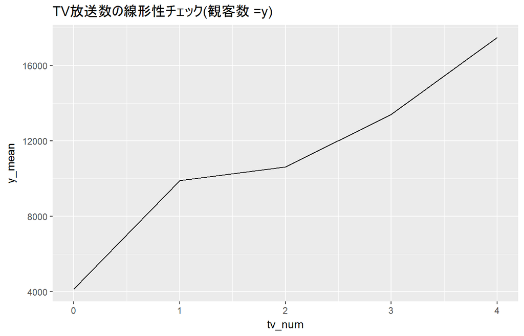

```r
## TV放送数の線形性チェック(観客数)
train %>%
    dplyr::group_by(tv_num) %>%
    dplyr::summarise(y_mean = mean(y)) %>%
    dplyr::ungroup(.) %>%
    ggplot(., aes(x = tv_num, y = y_mean)) +
    geom_line() + ggtitle("TV放送数の線形性チェック(観客数 =y)")
```

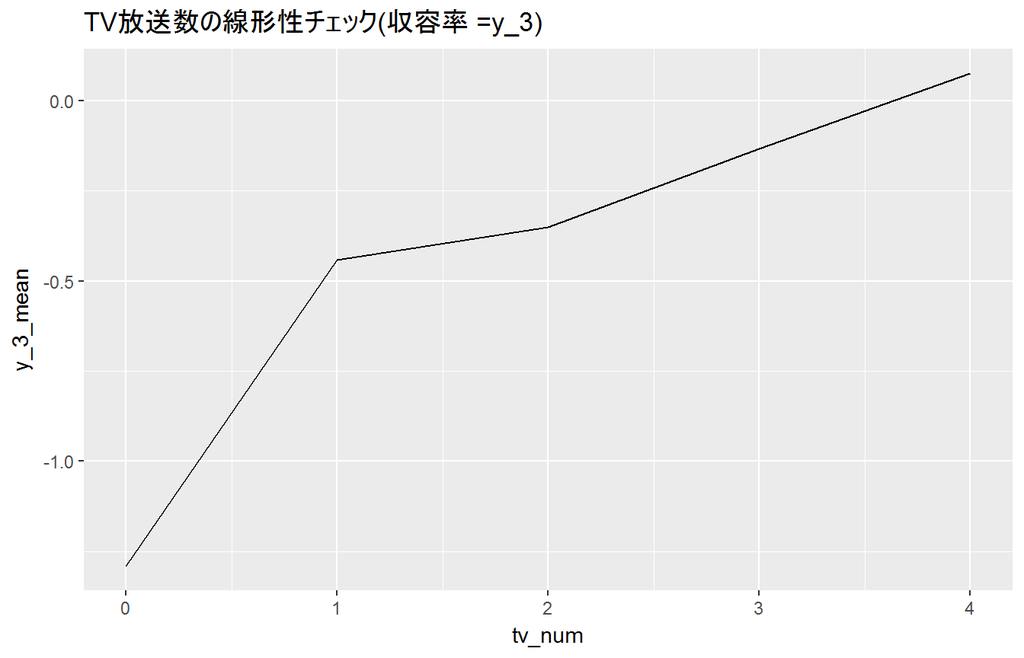

```r
## TV放送数の線形性チェック(収容率 y_3)
train %>%
    dplyr::group_by(tv_num) %>%
    dplyr::summarise(y_3_mean = mean(y_3)) %>%
    dplyr::ungroup(.) %>%
    ggplot(., aes(x = tv_num, y = y_3_mean)) +
    geom_line() + ggtitle("TV放送数の線形性チェック(収容率 =y_3)")
```

データ加工、線形化

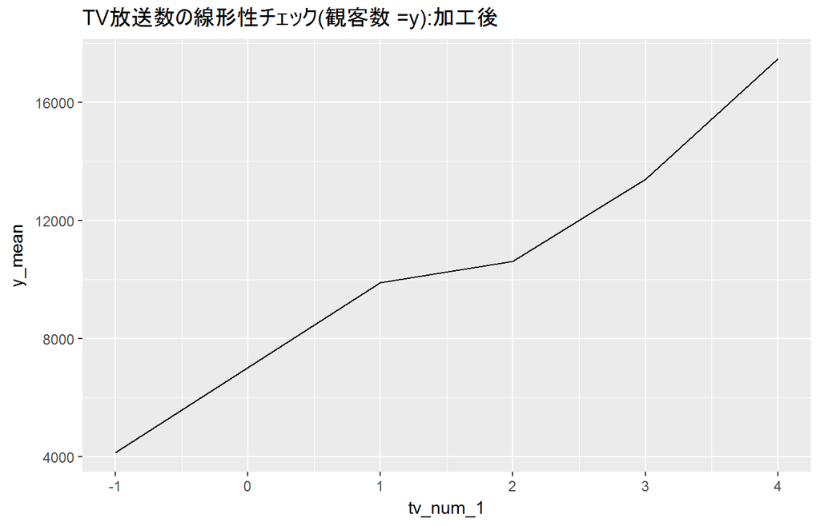

```r
train$tv_num_1 <- ifelse(train$tv_num == 0, -1, train$tv_num)
train$tv_num_2 <- ifelse(train$tv_num == 0, -2, train$tv_num)

## TV放送数の線形性チェック(観客数)
train %>%
    dplyr::group_by(tv_num_1) %>%
    dplyr::summarise(y_mean = mean(y)) %>%
    dplyr::ungroup(.) %>%
    ggplot(., aes(x = tv_num_1, y = y_mean)) +
    geom_line() + ggtitle("TV放送数の線形性チェック(観客数 =y):加工後")
```

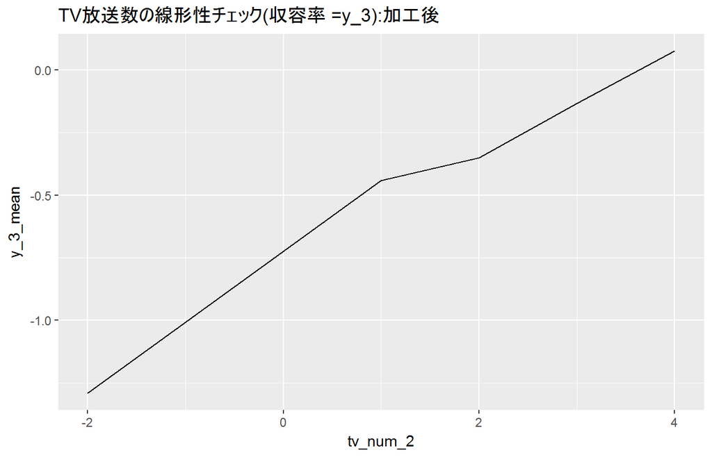

```r
## TV放送数の線形性チェック(収容率 y_3)
train %>%
    dplyr::group_by(tv_num_2) %>%
    dplyr::summarise(y_3_mean = mean(y_3)) %>%
    dplyr::ungroup(.) %>%
    ggplot(., aes(x = tv_num_2, y = y_3_mean)) +
    geom_line() + ggtitle("TV放送数の線形性チェック(収容率 =y_3):加工後")
```

# 4 Predictions and Residuals

```r
mod1 <- glm(y ~ tv_num_1, data=train, family=gaussian(link="identity"))
mod2 <- glm(y_3 ~ tv_num_2, data=train, family=gaussian(link="identity"))

train2 <- train %>%
    modelr::spread_predictions(mod1, mod2) %>%
    dplyr::rename(pred_1 = mod1, pred_y_3 = mod2) %>%
    dplyr::mutate(pred_1 = ifelse(pred_1 > capa, capa, pred_1),
                  pred_1 = ifelse(pred_1 < 0, 0, pred_1)) %>%
    dplyr::mutate(resid1 = y - pred_1) %>%
    dplyr::mutate(pred_2 = capa * (1 / (1 + exp(-pred_y_3)))) %>%
    dplyr::mutate(resid2 = y - pred_2) %>%
    glimpse
```

```
## Observations: 1,952
## Variables: 53
## $ id          <int> 13994, 13995, 13996, 13997, 13998, 13999, 14000, 1...
## $ y           <int> 18250, 24316, 17066, 29603, 25353, 11283, 18920, 1...
## $ year        <int> 2012, 2012, 2012, 2012, 2012, 2012, 2012, 2012, 20...
## $ stage       <chr> "Ｊ１", "Ｊ１", "Ｊ１", "Ｊ１", "Ｊ１", "Ｊ１", "Ｊ１", "Ｊ１", "Ｊ...
## $ match       <chr> "第１節第１日", "第１節第１日", "第１節第１日", "第１節第１日", "第１節第１日", ...
## $ gameday     <chr> "03/10(土)", "03/10(土)", "03/10(土)", "03/10(土)", "0...
## $ time        <chr> "14:04", "14:04", "14:04", "14:06", "14:04", "14:0...
## $ home        <chr> "ベガルタ仙台", "名古屋グランパス", "ガンバ大阪", "サンフレッチェ広島", "コンサドー...
## $ away        <chr> "鹿島アントラーズ", "清水エスパルス", "ヴィッセル神戸", "浦和レッズ", "ジュビロ磐田...
## $ stadium     <chr> "ユアテックスタジアム仙台", "豊田スタジアム", "万博記念競技場", "エディオンスタジアム広...
## $ tv          <chr> "スカパー／ｅ２／スカパー光／ＮＨＫ総合", "スカパー／ｅ２／スカパー光（Ｊ　ＳＰＯＲＴＳ　４）／...
## $ home_score  <int> 1, 1, 2, 1, 0, 0, 1, 0, 3, 1, 0, 1, 2, 2, 2, 2, 3,...
## $ away_score  <int> 0, 0, 3, 0, 0, 0, 0, 1, 3, 0, 2, 2, 1, 1, 1, 1, 2,...
```

[output cut: 40 more lines]

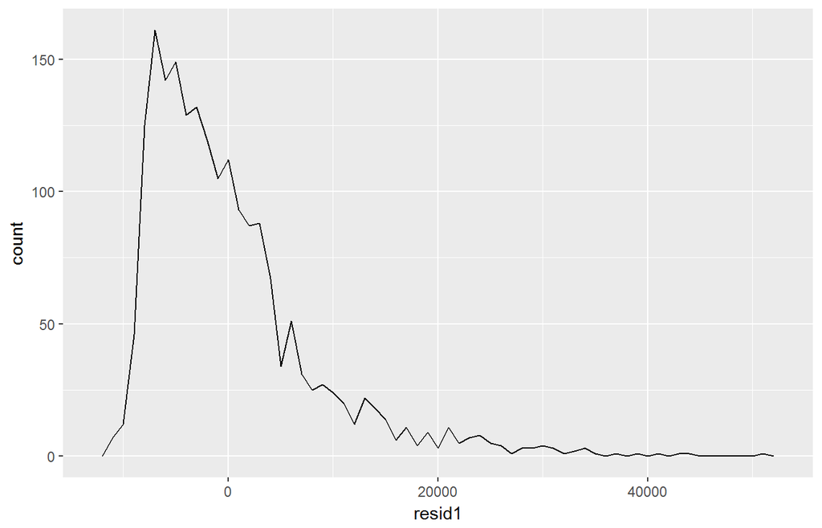

```r
ggplot(train2, aes(resid1)) +
    geom_freqpoly(binwidth = 1000)
```

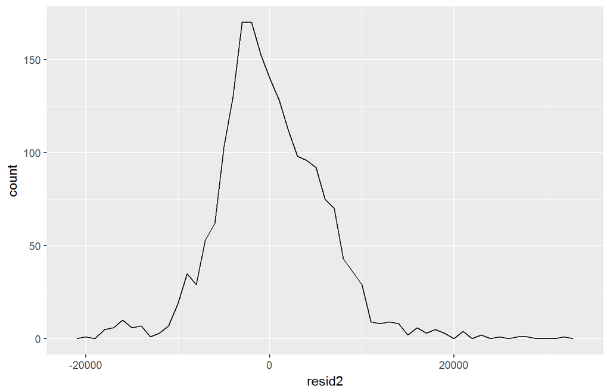

```r
ggplot(train2, aes(resid2)) +
    geom_freqpoly(binwidth = 1000)
```

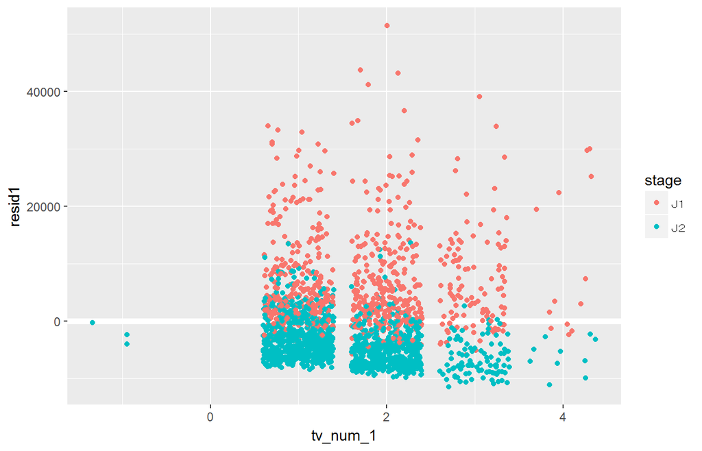

```r
ggplot(train2, aes(tv_num_1, resid1)) +
    geom_ref_line(h = 0) +
    geom_jitter(aes(colour = stage))
```

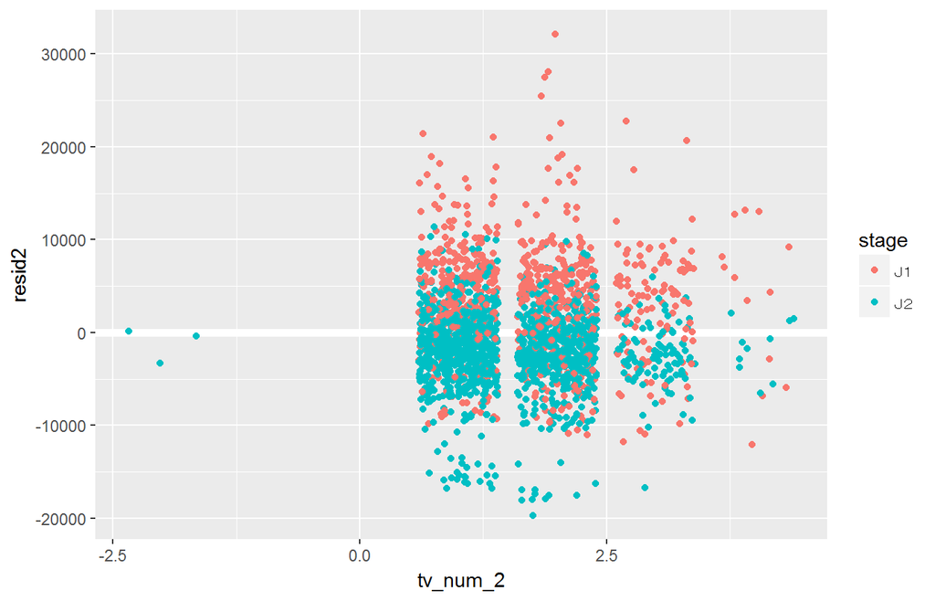

```r
ggplot(train2, aes(tv_num_2, resid2)) +
    geom_ref_line(h = 0) +
    geom_jitter(aes(colour = stage))
```